# Python_tutorial_07

Ji-Myoung Choi

2023-02

## 텍스트 파일을 분석하여 네트워크용 파일로 만들기

- 텍스트 파일에서 네트워크 분석을 위한 데이터 추출(노드(node)와 엣지(edge) 생성)
- 동시 출현 단어(word co-occurrence) 네트워크: 한 문서나 문장 내에서 같이 사용되는 단어들의 쌍을 추출하고 빈도를 계산
- 영화 대본의 등장 인물간 네트워크: 같은 씬에서 대화를 주고 받는 인물들은 서로 연관성이 있을 것이라는 전제에서 출발
- **nltk** 라이브러리를 사용한다. **nltk** 라이브러리는 텍스트 자료를 처리하기 위한 다양한 함수들과 모듈들이 내장되어 있다.
- **sklearn** 라이브러리에서 **sklearn.feature_extraction.text** 모듈을 사용한다. 여기에는 텍스트에서 정보를 추출하기 위한 다양한 함수들이 내장되어 있다.

#### Process

1. 동시 출현 단어(word co-occurrence) 네트워크: 한 문서나 문장 내에서 같이 사용되는 단어들은 서로 연관성이 있을 것이라는 전제에서 출발
   - 문서 혹은 문장에서 같이 사용되는 단어들의 쌍을 추출하고 빈도를 계산 후 2 X 2 차원의 데이터프레임을 만듦
   - csv 파일로 내보낸 후 gephi에서 처리
   - 데이터프레임을 gephi용 파일로 만든 후 저장, gephi에서 읽어 처리
2. 영화 대본의 등장 인물간 네트워크: 같은 씬에서 대화를 주고 받는 인물들은 서로 연관성이 있을 것이라는 전제에서 출발
   - 영화 대본을 씬으로 구분 후 각 씬에서 대화를 주고 받는 등장 인물들 이름을 추출
   - 각 씬을 하나의 문서 내지 문장으로 보고 여기서 동시 출현 인물,즉 인물들의 쌍과 빈도를 구해 데이터프레임으로 만듦
   - csv 파일로 내보낸 후 gephi에서 처리
   - 데이터프레임을 gephi용 파일로 만든 후 저장, gephi에서 읽어 처리

#### 1. 동시 출현 단어(word co-occurrence) 네트워크

1. 텍스트(Tesla라는 단어가 들어간 뉴스 기사 제목 100개)를 읽어온다.
2. 텍스트에서 불필요한 기호나 숫자 등을 삭제하고 불용어(stopwords)를 제거하는 등의 텍스트 정제 작업을 실시한다.
3. 각 문서에 나타나는 단어들의 발생 빈도를 구하여 텍스트를 문서-단어(document-term) 행렬로 만든다.
4. 문서-단어(document-term) 행렬을 단어-단어 행렬로 변환하여 두 단어간 동시 발생 빈도를 구한다.
5. 단어-단어 행렬을 데이터프레임으로 변환하여 csv 파일로 저장한다. 그리고 이 행렬을 네트워크 분석 도구인 gephi에서 읽을 수 있는 파일로 저장한다.

##### 텍스트 파일 정제

```python
with open('data/news_titles_tesla.txt', 'r') as f:
    news = f.read().splitlines()

news[:10]
```

```
## ['Tesla drastically lowers EV pricing in the US and Europe', 'Uber drivers in Europe can soon rent Polestar and Tesla EVs', 'The EV revolution became an eventuality in 2022', "Tesla's Model Y could fall foul of new EV tax credit eligibility rules", "NVIDIA's GeForce Now game streaming is coming t…
```

1. 1-2행: news_titles_tesla.txt 파일을 읽어 변수 *news*에 저장한다. **read()** 함수로 읽은 후에 **splitlines()**로 엔터()를 기준으로 라인들을 분리한다.
2. 4행: *news*를 10행까지만 출력한다.

```python
from nltk.tokenize import word_tokenize
from nltk.stem.porter import PorterStemmer
from nltk.corpus import stopwords

stemmer = PorterStemmer()
english_stopwords = stopwords.words('english')
english_stopwords.append('reuters')

news_cleaned = []
for sent in news:
    tokenized_sent = word_tokenize(text=sent)

    words = []
    for word in tokenized_sent:
        wrd_lower = word.lower()
        if (wrd_lower.isalpha()) and (wrd_lower not in english_stopwords):
            wrd_stem = stemmer.stem(wrd_lower)
            words.append(wrd_stem)

    cleaned_title = ' '.join(words)
    news_cleaned.append(cleaned_title)
```

```python
print(news_cleaned[:5])
```

```
## ['tesla drastic lower ev price us europ', 'uber driver europ soon rent polestar tesla ev', 'ev revolut becam eventu', 'tesla model could fall foul new ev tax credit elig rule', 'nvidia geforc game stream come car']
```

1. 1행: *news_cleaned*를 5개만 출력하여 정제된 결과를 확인한다. **print(news[:5])**의 결과와 비교하면 중요 단어들만 담겨있음을 알 수 있다.

##### 네트워크 노드(node)의 수 줄이기

- 동시 출현 단어 네트워크는 각 단어가 노드(node)가 되고, 이 단어들간의 관계(동일 맥락에서 같이 사용된 단어들)를 엣지(edge)로 표현한다. 너무 많은 단어들을 노드로 사용할 경우 네트워크의 생성에 오랜 시간이 걸리고 확인하기도 어려우므로 노드의 수를 제한한다.
- 아래 코드는 네트워크 그래프의 노드로 사용하기 위해 전체 단어들 중에서 가장 많이 사용된 상위 50개의 단어만 추출하는 단계이다.

```python
from collections import Counter
import pandas as pd

all_words = []
for title in news_cleaned:
    words = title.split(' ')
    all_words.extend(words)

freqs = Counter(all_words)

most_freq_wrds = freqs.most_common(50)

target_wrds = []
for tup in most_freq_wrds:
    target_wrds.append(tup[0])
```

```python
print(target_wrds)
```

```
## ['tesla', 'musk', 'car', 'ev', 'china', 'price', 'elon', 'new', 'electr', 'cut', 'say', 'twitter', 'futur', 'vehicl', 'trial', 'sale', 'ceo', 'worker', 'plan', 'rise', 'lower', 'europ', 'driver', 'model', 'fire', 'employe', 'deliv', 'record', 'cliff', 'california', 'big', 'year', 'tweet', 'week',…
```

1. 1행: *target_wrds*를 출력하면 50개의 단어를 볼 수 있다.

##### 동시 출현 단어(word co-occurrences) 데이터 만들기

- **sklearn** 라이브러리 활용
- 만약 No module named ‘sklearn’ 오류가 발생하면 이 라이브러리를 설치한다.
- pip install scikit-learn

```python
from sklearn.feature_extraction.text import CountVectorizer

cv = CountVectorizer(vocabulary=target_wrds)
docTerm = cv.fit_transform(news_cleaned)

docTerm_co = (docTerm.T * docTerm)
```

1. 1행: **sklearn.feature_extraction.text** 모듈에서 **CountVectorizer**를 불러와서 탑재한다. **CountVectorizer**는 문서들의 집합(리스트)을 문서를 구성하는 개별 단어와 그 단어의 빈도로 표현되는 2차원 행렬로 변환한다.
2. 3행: **CountVectorizer**는 일반적인 함수처럼 텍스트 집합을 항으로 넣지 않고(**CountVectorizer(news_cleaned)**) 텍스트를 변환할 때 필요한 조건들부터 설정한 후(vocabulary=target_wrds) 그 조건을 실행하는 **cv**와 같은 또 다른 객체에 할당한다. 여기서 조건은 문서들에서 *target_wrds*에 해당하는 50개의 단어만 추출하여 2차원 행렬로 만들라는 의미이다.
3. 4행: 객체 **cv**에 속한 **fit_transform** 함수로 *news_cleaned*를 행렬로 변환하여 *docTerm*에 저장한다. *docTerm*과 같은 데이터를 document-term matrix(문서-단어 행렬)라고 한다. 이 행렬의 차원 값을 확인하려면 **docTerm.shape**을 실행한다. 100(행) X 50(열)로 된 것을 알 수 있다. 100은 문서의 갯수, 50은 단어의 갯수이다.
4. 동시 출현 단어를 행렬로 표현하는 가장 쉬운 방법은 원래 행렬을 뒤집은(transpose) 행렬과 원래 행렬을 곱하는 것이다.
5. 6행: 동시 출현 단어의 행렬을 얻기 위해 원래 행렬의 뒤집은 형태를 구하고(**docTerm.T**) 그것을 원래의 행렬(*docTerm*)과 곱한다. 행렬의 곱셈은 *로 실행한다. **.T**가 transpose를 구현하는 함수이다. 이렇게 얻은 새 행렬을 *docTerm_co*에 저장한다.

```python
sp_df = pd.DataFrame.sparse.from_spmatrix(docTerm_co, index=target_wrds, columns=target_wrds)
sp_df.iloc[:10, :10]
```

```
##         tesla  musk  car  ev  china  price  elon  new  electr  cut
## tesla      47    10    5   6      8      8     4    3       0    7
## musk       10    19    0   0      0      0     8    2       0    0
## car         5     0   14   0      0      2     1    3       3    1
## ev          6     0    0  11      1      2     0    2       0    0
## china       8     0    0   1     10      5     0    0       0    5
## price       8     0    2   2      5      9     0    1       0    6
## elon        4     8    1   0      0      0     9    1       0    0
## new         3     2    3   2      0      1     1    7       0    0
## electr      0     0    3   0      0      0     0    0       7    0
## cut         7     0    1   0      5      6     0    0       0    7
```

```python
docTerm_co.setdiag(0)
```

1. 1행: 서로 같은 단어들간의 빈도를 구할 필요는 없으므로 대각선에 위치한 값들(tesla-tesla, musk-musk 등의 동일 단어간의 출현 빈도)을 **setdiag()**를 이용하여 0으로 바꾼다.

```python
sp_df = pd.DataFrame.sparse.from_spmatrix(docTerm_co, index=target_wrds, columns=target_wrds)
sp_df.iloc[:10, :10]
```

```
##         tesla  musk  car  ev  china  price  elon  new  electr  cut
## tesla       0    10    5   6      8      8     4    3       0    7
## musk       10     0    0   0      0      0     8    2       0    0
## car         5     0    0   0      0      2     1    3       3    1
## ev          6     0    0   0      1      2     0    2       0    0
## china       8     0    0   1      0      5     0    0       0    5
## price       8     0    2   2      5      0     0    1       0    6
## elon        4     8    1   0      0      0     0    1       0    0
## new         3     2    3   2      0      1     1    0       0    0
## electr      0     0    3   0      0      0     0    0       0    0
## cut         7     0    1   0      5      6     0    0       0    0
```

1. 1행: 대각선에 위치한 값들(tesla-tesla, musk-musk 등의 동일 단어간의 출현 빈도)이 모두 0으로 수정되었다. 이 데이터프레임을 csv 형식이나 gexf 형식으로 저장하여 gephi에서 불러와 네트워크를 그릴 수 있다.

```python
sp_df.to_csv('result/word_cooccurrence_test.csv')
```

1. 1행: *sp_df*를 csv 데이터베이스 포맷으로 저장한다. 이 csv 파일은 gephi에서 읽어들여 네트워크를 그릴 수 있다.

##### csv가 아닌 gephi 파일 포맷(gexf)으로 저장하기

```python
import networkx as nx

Graph = nx.from_pandas_adjacency(sp_df)
# nx.info(Graph)
nx.write_gexf(Graph, "result/cooccurrence_test_reduced.gexf")
```

1. 1행: 네트워크를 다루기 위한 라이브러리인 **networkx**를 **nx**라는 이름으로 탑재한다.
2. 3행: 데이터프레임인 *sp_df*를 네트워크 구조로 변환한다. 데이터프레임을 변환할 때는 **from_pandas_adjacency()** 함수를 이용한다. 변환된 네트워크 그래프를 *Graph*에 저장한다.
3. 4행: **write_gexf()** 함수로 *Graph*를 gephi 툴의 입력 파일로 저장한다. 이 파일을 gephi에서 불러와서 그래프를 그린다.

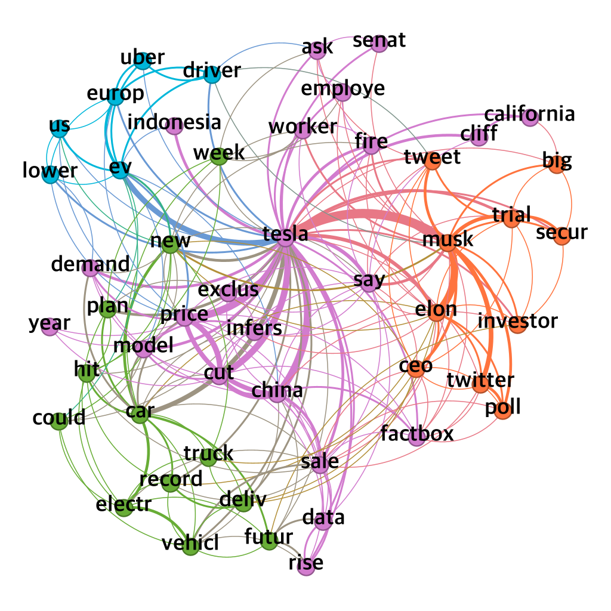

#### 2. 영화 대본의 등장 인물간 관계 네트워크

- 영화 Love actually의 각 씬(scene)에서 동시에 등장하는 인물들(즉 서로 같은 공간에 있으면서 대화를 나누는 인물들)은 서로 관련이 있다는 것을 전제
- 위에서 설명한 word co-occurrence와 동일한 개념. 여기서는 단어 대신 각 씬에 등장하는 인물 이름간의 관계 즉 인물의 동시 출현(co-occurrence)을 계산
- 다음과 같이 단계로 영화의 등장 인물간 관계 네트워크를 그릴 수 있다.
1. 영화 대본 파일(Love Actually)을 읽어온다.
2. 텍스트에서 불필요한 기호나 숫자 등을 삭제하고 빈 행을 제거하는 등의 텍스트 정제 작업을 실시한다.
3. 전체 문서를 씬(scene)별로 나눈다. 이는 씬 단위로 구분하여 같이 등장하는 인물들을 확인해야 하기 때문이다.
4. 각 씬에서 등장 인물 이름만 남기고 대사와 지문은 삭제한다. 이로써 등장 인물명을 개별 단어처럼 취급할 수 있다.
5. 각 씬에 나타나는 인물들의 등장 빈도를 구하여 씬-인물명(document-term) 행렬로 만든다.
6. 씬-인물명(document-term) 행렬을 인물명-인물명 행렬로 변환하여 두 인물간 동시 등장 빈도를 구한다.
7. 인물명-인물명 행렬을 데이터프레임으로 변환하여 csv 파일로 저장한다. 그리고 이 행렬을 네트워크 분석 도구인 gephi에서 읽을 수 있는 파일로 저장한다.

```python
with open('data/love_actually.txt', 'r') as f:
    raw_script = f.readlines()

raw_script[:10]
```

```
## ['Love Actually Scripts\n', '\n', '\n', '\n', '[ Scene #1 ]\n', "(Man): 'Whenever I get gloomy with the state of the world, \n", "  I think about the arrival's gate at Heathrow airport. \n", '  General opinion started to make out that we live in a world of hatred and greed, \n', "  but I don't se…
```

1. 1-2행: love_actually.txt 파일을 읽어 *raw_script*에 저장한다.
2. 4행: *raw_script*의 첫 10행을 출력한다.

```python
script = []
for line in raw_script:
    line = line.strip()
    if line != '':
        script.append(line)

script[:10]
```

```
## ['Love Actually Scripts', '[ Scene #1 ]', "(Man): 'Whenever I get gloomy with the state of the world,", "I think about the arrival's gate at Heathrow airport.", 'General opinion started to make out that we live in a world of hatred and greed,', "but I don't see that. Seems to me that love is ever…
```

1. 1행: 리스트 변수 *script*를 만든다. 여기에는 불필요한 문자(‘’)를 없애고 빈 행을 없앤 대본을 저장할 것이다.
2. 2행: 위에서 읽은 *raw_script* 파일에서 한 줄씩 가져와 *line*에 할당하고
3. 3행: 이 *line*에서 불필요한 문자(‘’)를 없앤 후 다시 변수 *line*에 저장한다.
4. 4행: 이 때 만약(**if**) 이 *line*이 빈 행(’’)이 아니라면
5. 5행: 변수 *script*에 차례로 추가한다. 만약 빈 행이면 추가하지 않고 넘어간다.
6. 7행: 새로 만든 대본 리스트 *script*를 10행까지만 출력한다. 첫 행에 ’Love Actually Scripts’라는 영화 제목이 있음을 볼 수 있다.

```python
script = script[1:-1]
script[:10]
```

```
## ['[ Scene #1 ]', "(Man): 'Whenever I get gloomy with the state of the world,", "I think about the arrival's gate at Heathrow airport.", 'General opinion started to make out that we live in a world of hatred and greed,', "but I don't see that. Seems to me that love is everywhere.", "Often it's not…
```

1. 1행: *script*에서 제일 첫 줄과 마지막 줄을 삭제한다. 첫 줄에는 영화 제목이, 마지막 줄에는 영화의 끝을 알리는 “[The end]”가 저장되어 있다. [1:-1]은 두 번째 줄부터 슬라이싱을 하되 마지막 줄(-1)을 제외한 곳까지만 슬라이싱을 한다는 의미이다.
2. 2행: *script*를 10행까지만 다시 출력한다. 영화 제목이 삭제된 것을 볼 수 있다.
- 불필요한 라인들을 모두 삭제했으므로 이제 대본을 씬 별로 분리하기만 하면 된다.
- 먼저 씬 구분 라인을 찾아서 해당 위치값을 저장하여 이 위치값으로 각 씬의 시작과 끝을 확인한다.

```python
import re

scene_idx = []
for i, line in enumerate(script):
    if re.search('\\[ Scene #\\d{1,2} \\]', line):
        scene_idx.append(i)

scene_idx.append(len(script))

print(len(scene_idx))
```

```
## 80
```

```python
scene_idx.append(len(script))
```

1. 1행: 전체 대본을 씬 단위로 분리하려면 각 씬의 시작 위치와 끝 위치에 대한 정보가 있어야 한다. 79개 씬 중 78번째까지는 시작 위치와 끝 위치를 알 수 있으나 79번째 씬의 끝 위치는 알 수가 없다. *scene_idx*에는 씬의 시작 위치만 저장되어 있기 때문이다. 따라서 79번째 씬의 끝나는 위치 즉 *script*의 마지막 줄의 위치값을 추가해 주어야 한다. 이로써 79번째 씬의 끝 위치 정보도 얻게 되었다.

```python
print(scene_idx)
```

```
## [0, 11, 26, 37, 51, 56, 62, 71, 101, 112, 124, 143, 153, 172, 175, 191, 218, 255, 268, 278, 293, 314, 326, 346, 365, 368, 370, 399, 407, 423, 446, 459, 480, 485, 518, 533, 554, 567, 573, 606, 641, 646, 656, 677, 681, 687, 703, 717, 725, 738, 772, 780, 787, 843, 849, 858, 874, 936, 956, 965, 974, …
```

1. 1행: *scene_idx* 전체를 출력한다.

```python
srt_end_pairs = []
for id_pair in zip(scene_idx[0:], scene_idx[1:]):
    srt = id_pair[0] + 1
    end = id_pair[1]
    srt_end_pairs.append((srt, end))
```

1. 1행: 각 씬의 시작 위치와 끝 위치를 저장할 빈 리스트 변수 *srt_end_pairs*를 만든다.
2. 2행: 위에서 출력한 *scene_idx*를 살펴보면 씬의 시작 위치와 끝 위치를 알 수 있다. 즉 [0, 11, 26]에서 첫 번째 씬의 내용 시작(’[ Scene #1 ]’를 제외한)은 첫 번째 요소인 0에 1을 더한 1이고, 끝은 두 번째 요소인 11이다. 두 번째 씬의 시작 위치는 두 번째 요소 11에 1을 더한 12이고 끝 위치는 26이다. 이와 같이 씬 위치 값을 둘씩 쌍을 지어 각 씬의 내용 시작과 끝 위치를 구하게 된다.
3. 2행: 두 개의 리스트에서 요소를 각각 하나씩 가져와서 쌍으로 만든 후 다른 변수에 할당할 때는 **zip()** 함수를 사용할 수 있다. **zip(scene_idx[0:], scene_idx[1:])**에서 *scene_idx[0:]*는 씬의 시작 위치를, *scene_idx[1:]*는 끝 위치를 가리킨다. 이 결과로 (0, 11), (11, 26), … 등의 위치 쌍 정보를 얻는다. 이 쌍 정보는 *id_pair*에 저장된다.
4. 3행: *id_pair*의 첫 번째 요소에 1을 더한 값을 시작 위치 변수 *srt*에 할당한다.
5. 4행: *id_pair*의 두 번째 요소의 값을 끝 위치 변수 *end*에 할당한다.
6. 5행: *srt*와 *end*를 튜플로 만든 후(*(srt, end)*) *srt_end_pairs*에 차례로 저장한다.

```python
scene_texts = []
for id_pair in srt_end_pairs:
    scene = script[id_pair[0]:id_pair[1]]
    # scene = ' '.join(scene)
    scene_texts.append(scene)
```

1. 1행: 분리한 각 씬을 저장할 리스트 변수 *scene_texts*를 만든다.
2. 2행: *srt_end_pairs*에서 위치 정보 쌍을 하나씩 가져와서 *id_pair*에 할당하고
3. 3행: id_pair[0] 즉 쌍의 첫 번째 값에서 시작하여 id_pair[1] 즉 쌍의 두 번째 값까지 *script*를 슬라이싱한다. *scene*에는 각 씬의 내용들(대사 및 지문)만 저장된다.
4. 4행: *scene*을 *scene_texts*에 차례대로 저장한다.

```python
print(scene_texts[1])
```

```
## ['Billy: ♪ I feel it in my fingers ♪ I feel it in my toes ♪ Feel it in my toes, yeah ♪', 'Love is all around me And so the... ♪', "Joe: I'm afraid you did it again, Bill.", "Billy: It's just I know the old version so well, you know.", "Joe: Well, we all do. That's why we're making the new version…
```

1. 1행: *scene_texts*의 두 번째 씬을 출력한다. 등장 인물 Billy와 Joe의 대사들을 확인할 수 있다. 이 씬에는 이 두 명이 동시에 등장하여 대화를 나눈다.
- 대본의 등장 인물과 그 인물을 연기한 배우의 이름이 담긴 데이터 파일을 이용하여 대본에 나타나는 등장 인물 이름에 배우 이름을 넣어준다.

```python
import pandas as pd

char_cast = pd.read_csv('data/love_actually_cast.csv')
char_cast.head(5)
```

```
##   speaker          actor
## 0      PM     Hugh Grant
## 1  Daniel    Liam Neeson
## 2   Harry   Alan Rickman
## 3   Jamie    Colin Firth
## 4   Karen  Emma Thompson
```

1. 1행: csv 파일을 읽기 위해 라이브러리 **pandas**를 *pd*라는 이름으로 탑재한다.
2. 3행: 등장 인물과 그 인물을 연기한 배우의 이름이 담긴 love_actually_cast.csv 파일을 읽어 *char_cast*에 저장한다.
3. 4행: *char_cast*를 5행만 출력한다. 등장 인물명(speaker)가 첫 번째 열에, 배우 이름이 두 번째 열에 위치한다.

```python
print(char_cast[char_cast['speaker'].str.contains('Billy')]['actor'].to_list()[0])
```

```
## Bill Nighy
```

- 이 코드 라인은 등장 인물명으로 배우 이름을 찾기 위한 것이다. 즉 Billy를 어떤 배우가 연기했는지 찾는다. 이를 이용해 등장 인물 모두에 대한 배우명을 찾을 수 있다.
1. **char_cast[char_cast[‘speaker’].str.contains(‘Billy’)]**: 데이터프레임 *char_cast*의 ‘speaker’ 열을 문자열로 만든 후(**str**), 거기에 ’Billy’라는 문자열이 포함되어 있는지 여부를 true, false로 반환한다. 포함되어 있으면 true, 그렇지 않으면 false를 반환한다. 데이터프레임 *char_cast*의 행에서 이 값에 해당하는 것만 선택한다.
2. **char_cast[char_cast[‘speaker’].str.contains(‘Billy’)][‘actor’].to_list()**: 선택한 행(9번 행)에서 ‘actor’ 열만 가져온 후 그것을 리스트로 변환한다(**.to_list()**).
3. char_cast[char_cast[‘speaker’].str.contains(‘Billy’)][‘actor’].to_list()[0]: 변환한 리스트를 문자열로 바꾼다. 이 리스트에는 하나의 요소만 있으므로 첫 번째 값만 가져오면 된다.
4. 출력하면 배우 이름 Bill Nighy를 얻을 수 있음을 알 수 있다.

```python
chars_per_scene = []
for text in scene_texts:
    chars = [re.search('^[a-zA-Z]+:', line).group() for line in text if re.search('^[a-zA-Z]+:', line) is not None]
    chars = [re.sub(':', '', char) for char in chars]
    char_actor = []
    for char in chars:
        if char in char_cast['speaker'].to_list():
            actor = char_cast[char_cast['speaker'].str.contains(char)]['actor'].to_list()[0]
            actor = re.sub(' ', '_', actor)
            char_actor.append(char + '(' + actor + ')')
        # else:
        #     continue
    char_actor_ = ' '.join(char_actor)
    chars_per_scene.append(char_actor_)
```

```python
chars = []
for line in scene_texts[1]:
    if re.search('^[a-zA-Z]+:', line) is not None:
        x = re.search('^[a-zA-Z]+:', line).group()
        chars.append(x)

chars_1 = [re.sub(':', '', char) for char in chars]

print(chars_1)
```

```
## ['Billy', 'Joe', 'Billy', 'Joe', 'Billy', 'Billy', 'Billy', 'Joe']
```

```python
print(len(chars_per_scene))
```

```
## 80
```

```python
chars_per_scene = [scene for scene in chars_per_scene if scene != '']
```

- 등장 인물이 없이 배경음만 있거나 지문만 있는 씬도 있을 수 있으므로 그런 씬들을 제외한다.
1. 1행: *chars_per_scene*에서 씬을 하나씩 가져와 *scene*에 할당하고 만약 *scene*이 아무 정보가 없는 게 아니라면 이 *scene*을 모두 *chars_per_scene*에 다시 저장한다. 이 역시 list comprehension을 이용한 것이다.

```python
chars_per_scene[0]
```

```
## 'Billy(Bill_Nighy) Joe(Gregor_Fisher) Billy(Bill_Nighy) Joe(Gregor_Fisher) Billy(Bill_Nighy) Billy(Bill_Nighy) Billy(Bill_Nighy) Joe(Gregor_Fisher)'
```

1. 1행: *chars_per_scene*의 첫 번째 요소를 출력한다. 등장 인물명으로만 이루어진 문장을 볼 수 있다.
- 등장 인물 목록 만들기

```python
all_chars = [char.split(' ') for char in chars_per_scene]
all_chars_ = []
for chars in all_chars:
    all_chars_.extend(chars)

unique_chars = list(set(all_chars_))
print(unique_chars)
```

```
## ['Sarah(Laura_Linney)', 'Daniel(Liam_Neeson)', 'Natalie(Martine_McCutcheon)', 'Tony(Abdul_Salis)', 'Jamie(Colin_Firth)', 'Jack(Martin_Freeman)', 'Billy(Bill_Nighy)', 'Peter(Chiwetel_Ejiofor)', 'Sam(Thomas_Sangster)', 'Karl(Rodrigo_Santoro)', 'Karen(Emma_Thompson)', 'Juliet(Keira_Knightley)', 'Mar…
```

1. 1행: *chars_per_scene*에서 한 씬씩 가져와서 *char*에 할당하고 *char*를 공백을 기준으로 분리한다. 결과는 인물명이 여러 개 들어있는 리스트이다. 이 리스트를 상위 리스트에 하나씩 추가한다. 리스트 *all_chars*에는 리스트들이 요소로 들어있다. 2행부터는 이중 구조의 리스트를 단순하게 만드는 과정이다.
2. 2행: 모든 씬의 인물명을 모두 저장할 리스트 *all_chars_*를 만든다.
3. 3행: *all_chars*에서 하나씩 가져와서 *chars*에 할당하고(이 때 *chars*는 한 씬 내의 인물명들이 담긴 리스트이다)
4. 4행: *chars*를 *all_chars_*에 추가한다. 이 때 리스트 안에 담긴 요소들을 추가하는 것이므로 **append()**가 아니라 **extend()** 함수를 사용한다.
5. 6행: *all_chars_*에는 씬마다 등장하는 인물명을 그대로 담고 있으므로 중복이 많다. 여기서 고유한 인물명만 얻기 위해 **set()** 함수를 사용한 후 그 결과를 리스트로 변환하여(**list()**) *unique_chars*에 저장한다.
6. 7행: *unique_chars*를 출력한다.

```python
del unique_chars[0]
print(unique_chars)
```

```
## ['Daniel(Liam_Neeson)', 'Natalie(Martine_McCutcheon)', 'Tony(Abdul_Salis)', 'Jamie(Colin_Firth)', 'Jack(Martin_Freeman)', 'Billy(Bill_Nighy)', 'Peter(Chiwetel_Ejiofor)', 'Sam(Thomas_Sangster)', 'Karl(Rodrigo_Santoro)', 'Karen(Emma_Thompson)', 'Juliet(Keira_Knightley)', 'Mark(Andrew_Lincoln)', 'PM…
```

```python
from sklearn.feature_extraction.text import CountVectorizer
import pandas as pd
import networkx as nx

# cv = CountVectorizer(lowercase=False, token_pattern='[a-zA-Z]+\([a-zA-Z_]+\)+', vocabulary=unique_chars)
cv = CountVectorizer(lowercase=False, token_pattern='[a-zA-Z]+\([a-zA-Z_]+\)+')
# cv = CountVectorizer(lowercase=False, token_pattern='[a-zA-Z]+\([a-zA-Z_]+\)+')
docTerm = cv.fit_transform(chars_per_scene)

docTerm_co = (docTerm.T * docTerm)
docTerm_co.setdiag(0)

names = cv.get_feature_names_out()

df = pd.DataFrame(data=docTerm_co.toarray(), columns=names, index=names)
# df.shape

Graph_LA = nx.from_pandas_adjacency(df)
nx.write_gexf(Graph_LA, "result/chars_interactions_loveActually_test_3.gexf")
```

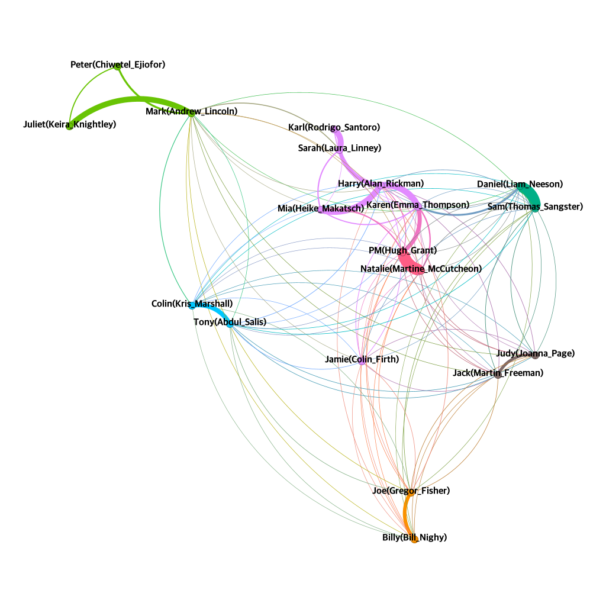